# Storytelling & Visualizations

Dan Ladd

**I’ve compiled visualizations below from several different projects. After extracting and preprocessing data, visualizations provide insights and guide me throughout my EDA process. I find loading cleaned data into proprietary software like Power BI or Tableau is more constraining than using object oriented programming languages like R or Python. However, there should always be considerations regarding project efficiency, collaborations, and final presentation when deciding between coding environments and “click-and-play” software.You’ll notice my first example was built using “click-and-play” software. This was one such situation.**

**In the reamining examples below, I primarily use the tidyverses ggplot library to script visualizations in R. Ggplot is rooted in the Grammar of Graphics and it’s layering capabilities gives me tremendous flexibility and customization. Additionally, I can quickly update the objects being mapped to graphics which allows me to quickly explore different perspectives of my data and adapt visualizations to new insights or requirements. This tool is vital for digging into data and telling its story. It lets me effortlessly play around with colors, shapes, and slices of data, helping me spot hidden patterns and insights.**

### **Histogram**

Histograms are well recognized frequency distribution plots. They’re commonly used to explore continuous numerical features but can also provide value to discrete features.

This Histogram was created in SpotFire, analytical software similar to Power BI and Tableau. It reveals a normal distribution in the prices customers paid for computers at a major retailer.. We can see that the most computers sold for between roughly 450 and 550 dollars. As prices deviate further from this center, the frequency of sales decreases, indicating fewer customers opted for computers at either higher or lower price points. This histogram helps us identify the most common price points, provides insight into purchasing behavior, and can be used to help support pricing or inventory strategies.

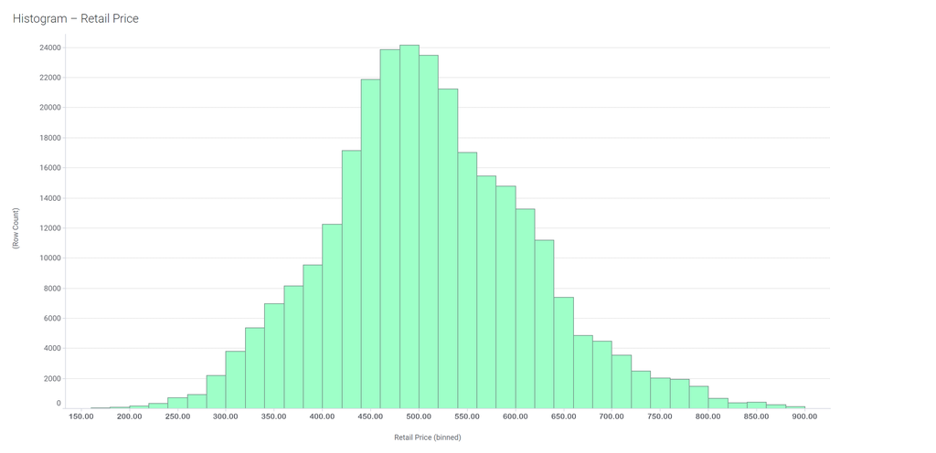

```r
include_graphics(hidden_url)
```

### **Scatter Plot**

Scatter plots are primarily used to visualize relationships between two or more continuous variables, but can also be used for discrete variables. They make it easy to spot patterns, trends, and potential correlations while also revealing the strength and direction of those relationships.

This scatter plot came with some interesting discoveries. The scatter plots Income and lot size variables do not appear to be correlated. They seem independent from one another. However, when I introduce riding lawn mower ownership into the plot using color, we can clearly see that income and lot size have a relationship with riding lawn mower ownership. It may have seemed predictable that people who own riding lawn mowers have both larger lots and larger incomes. This scatter plot helps solidify that hypothesis. More importantly however, the scatter plot gives us insight into how income and lot size effect riding lawn mower purchasing behaviors. It’s clear in the plot that prospects who make more than $70,000 are more likely to purchase a riding lawnmower regardless of lot size. We can also see that people who have lot sizes larger than 19,000 square feet also are more likely to purchase riding mowers regardless of income.

Further analysis on this discovery could provide more discrete insights to sales and marketing teams allowing them to more efficiently and effectively target the audiences that are most likely to buy.

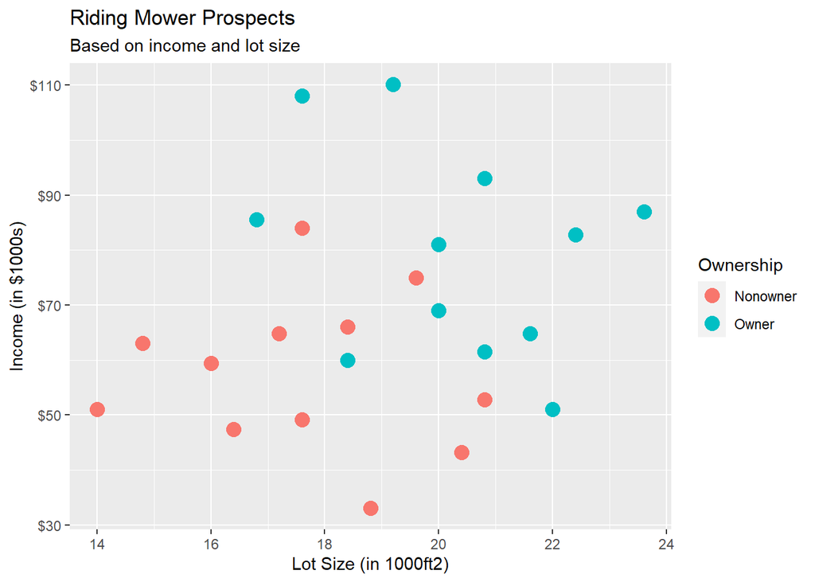

```r
ggplot(data = riding_mowers, mapping = aes(x = Lot_Size, y = Income, color = Ownership))+
  geom_point(size = 4) +
  scale_y_continuous(labels = dollar_format(prefix = "$")) +
  labs(title = "Riding Mower Prospects", subtitle = "Based on income and lot size", y = "Income (in $1000s)", x = "Lot Size (in 1000ft2)")
```

### **Bar Plot**

Bar plots are very versatile and fundamental for exploratory data analysis, offering a clear and concise way to uncover patterns and distributions within categorical data. Their a powerful tool for communicating insights, particularly in group comparisons or category ranks. Bar plots are a cornerstone of effective data visualization.

This bar plot shows average loan rates for each categorical loan grade. We can easily see that as loan grade declines, average interest rates increase. This is as we would expect in a loan portfolio, reflecting the higher risk associated with lower-grade loans. However, the bar plot also suggests consistency in rate determination, indicating that the grading system effectively differentiates risk levels. This pattern provides confidence in the alignment between loan grades and the corresponding interest rates, reinforcing the credibility of the risk assessment framework used in the portfolio.

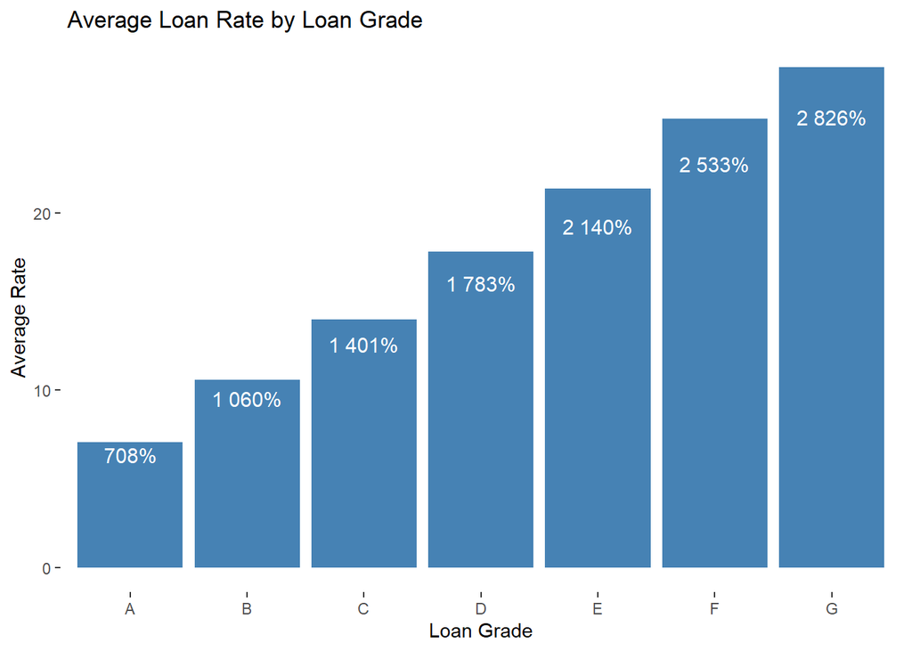

```r
lc_stack <- bind_rows(lc_2012, lc_2013, lc_2014, lc_2015, lc_2016, lc_2017)

p1_data <- lc_stack %>%
  mutate(int_rate = as.numeric(gsub("[^0-9.]", "", int_rate))) %>%
  group_by(grade) %>%
  summarise(avg_int_rate = mean(int_rate, na.rm = TRUE)) %>%
  filter(!is.na(avg_int_rate) & grade != "")

p1 <- ggplot(p1_data, mapping=aes(x = grade, y = avg_int_rate))+
  geom_bar(stat= "identity", fill="steel blue")+
  labs(x="Loan Grade",y="Average Rate", title=" Average Loan Rate by Loan Grade")+
  geom_text(aes(label=scales::percent(avg_int_rate), y=avg_int_rate),
               position=position_stack(vjust=0.9), color="white", size=4)+
  theme(panel.background = element_blank())

p1
```

### **Faceted Line Plot**

Line plots are crucial for time series analysis as they visualize how a feature changes over time. They help us understand dynamics like seasonality, long-term trends, and sudden shifts in behavior. Line plots highlight time based patterns that are critical to forecasting.

To help me gain an understanding of how opiate deaths differ from region to region in the US, I facet multi-line plots by US Census division. I also utilize a trend line in each faceted plot so we can compare regions to one another. This visualization presents a wealth of information in a clear, uncluttered view of each state and region, while also allowing us to compare any of the 50 states.

At first look we see that in all regions and in the US as a whole, opiate deaths increased from 1999 to 2014. This isn’t a big surprise to most informed people in the aftermath of the opiate crisis. However, we can see that the rate of increase varies across states and regions. For example, the New England region saw a spike around 2010, with New Hampshire’s own significant increase in deaths driving the region’s overall spike from 2011 to 2014. West Virginia contributed disproportional to death rates in the South Atlantic region. The peaks and troughs are pronounced suggesting differences in the timing and severity of the opiate crisis in that state. By identifying regional patterns, we can better understand how local factors such as healthcare access, socioeconomic conditions, and policies may have influenced the timing and severity of the opiate crisis, allowing for more targeted and effective intervention.

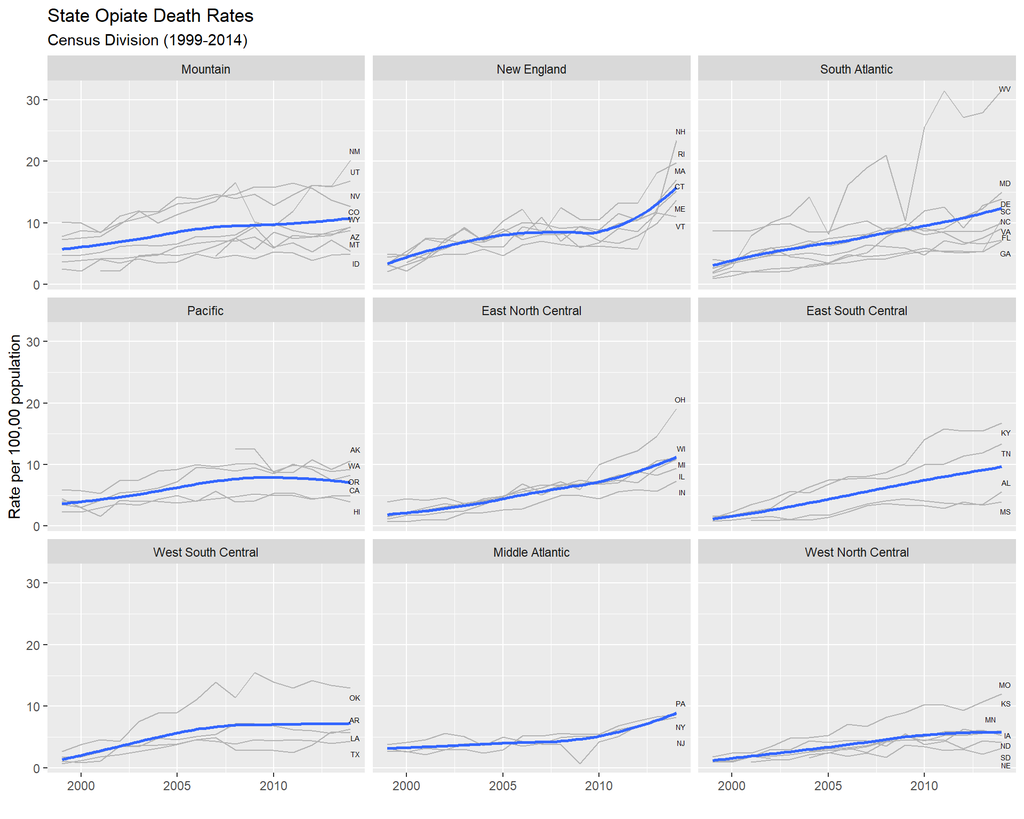

```r
p2 <- ggplot(data=drop_na(opiates,division_name),mapping = aes(year,adjusted))+
  geom_line(color="Grey70",mapping=aes(group=state)) +
  geom_smooth(mapping = aes(group=division_name),se=FALSE)+
  geom_text_repel(data=subset(opiates,year==max(year) & abbr !="DC"),mapping=aes(year,adjusted, label=abbr),size=1.8,segment.color=NA,nudge_x=30)+
  coord_cartesian(c(min(opiates$year),max(opiates$year)))+
  labs(x="",y="Rate per 100,00 population",title = "State Opiate Death Rates", subtitle = "Census Division (1999-2014)")+
  facet_wrap(~reorder(division_name,-adjusted, na.rm=TRUE),nrow=3)

p2
```

### **Multivariate Box Plot**

Box plots are one of the most informative methods for visualizing numerical variables against discrete classes. They provide a tremendous amount of information about the spread and dispersion of data. I regularly use box plots during my EDA process.

In this example, I create a multivariate box plot using three dimensions of data. The plot shows organ donor counts by country and then uses color to visualize if each countries organ donor law is informed or presumed. We can see that each countries box plot is unique in spread and dispersion. Some countries like Canada and Germany have consistent donor rates, while other countries like Spain and Italy vary more. Additionally, most presumed law countries have a high number of donors per million in population. This plot provides great insights and is also important to progressing forward in my EDA process. For example, after seeing this plot, I may want to take a closer look and make some inferences about why Spain is more dispersed or why the US and Ireland have high donorship in comparison to their informed law counterparts.

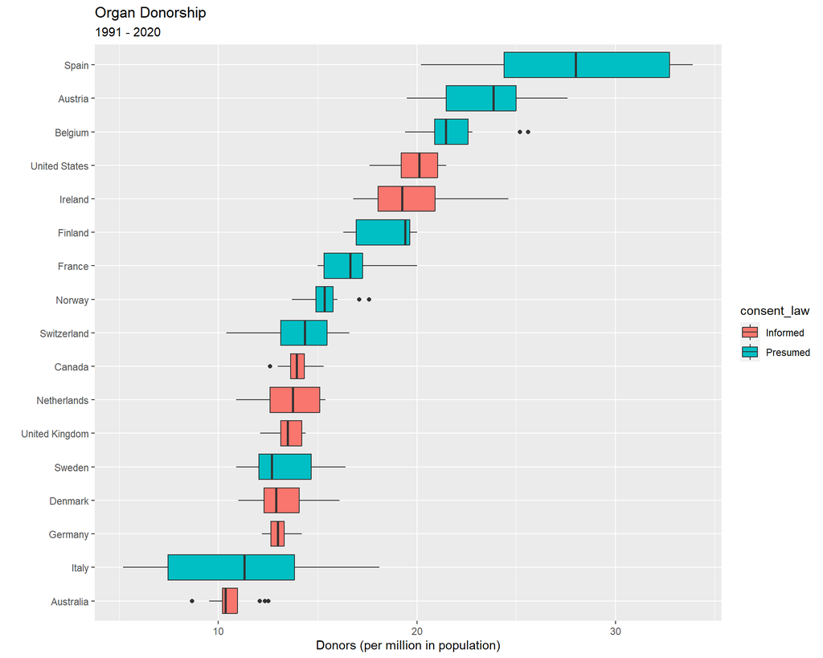

```r
p3 <- ggplot(data=organdata,mapping = aes(x=reorder(country,donors, na.rm=TRUE),y=donors,fill=consent_law)) +
  geom_boxplot()+
  labs(x = "", y = "Donors (per million in population)", title = "Organ Donorship", subtitle = "1991 - 2020")+
  coord_flip()

p3
```

### **Pairwise Correlation Matrix Heatmap**

Correlation matries are helpful for quickly identifying relationships between numerical variables. They highlight strong positive or negative correlations and are valuable in multicollinearity detection. It also guides feature selection by visualizing redundancy in variables. This makes it a powerful tool for exploratory data analysis and an essential tool for optimizing models.

This correlation heatmap shows how attributes and characteristics are correlated in relation to employee attrition. There are no negative correlations between variables. However, there are several strong positive correlations between variables, as evidenced by a darker tone of blue and correlation values greater than 0.5. It’s unlikely that multicollinearity is an issue, given that the strongest correlation is 0.77. However, it’s worth investigating further to understand the specific relationships between these variables and their potential impact on attrition.

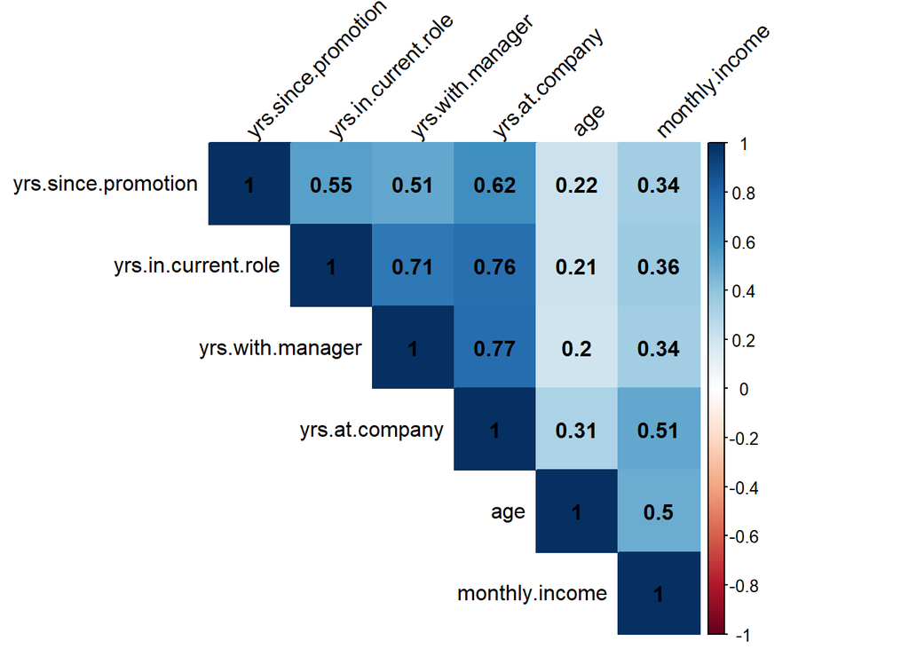

```r
cor_matrix <- cor(desc_stat_num_vars)

corrplot(cor_matrix, method = "color", type = "upper", order = "hclust",
         addCoef.col = "black", tl.col = "black", tl.srt = 45)
```

### **Map Plot**

Map plots make lasting impressions when presenting geographically related data by providing a clear visual representation of spatial patterns and trends. They are especially useful for understanding regional differences, distributions, and concentrations of data, such as sales performance across locations or population density in different areas. Their visual appeal and clarity make them a great choice for storytelling, especially when location plays a key role.

This map plot provides a clear visualization of the results from the 2016 US Presidential Election. It highlights the geographic distribution of support, showing that the Mid-Atlantic coast, Northeast, and West Coast largely leaned toward the Democratic Party, while the interior and Southern U.S. favored the Republican Party. This spatial representation makes it easy to identify regional voting patterns and trends, offering valuable insights into the election’s geographic dynamics.

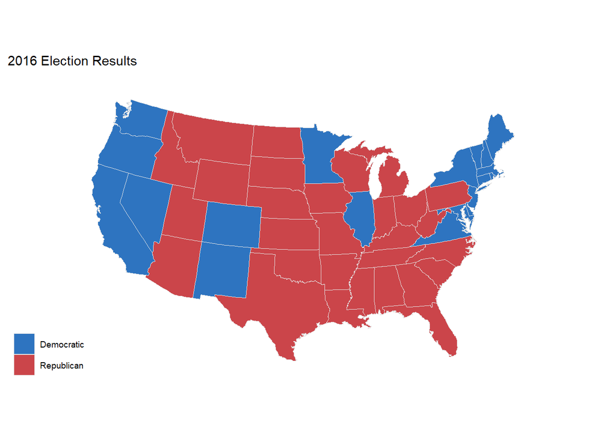

```r
us_states <- map_data("state")

election$region <- tolower(election$state)
us_state_elec <- left_join(us_states,election)

party_colors <- c("#2E74C0","#CB454A")


p4 <- ggplot(us_state_elec,mapping = aes(long,lat,group=group,fill=party)) +
  geom_polygon(color="grey90",size=0.1)+
  coord_map(projection="albers",lat0=39,lat1=45)+
  scale_fill_manual(values=party_colors)+
  labs(title="2016 Election Results",fill=NULL)+
  theme_map()

p4
```